# Установка библиотек

# Тематическое моделирование

Существует несколько способов тематического моделирования, которые могут быть использованы для анализа больших наборов текстовых данных. Ниже перечислены некоторые из них:

1)Latent Dirichlet Allocation (LDA) - это один из наиболее популярных методов тематического моделирования, который использует статистические методы для выявления скрытых тем в наборе текстовых данных. LDA моделирует каждый документ как распределение вероятностей по темам, а каждую тему как распределение вероятностей по словам.

2)Non-negative Matrix Factorization (NMF) - это метод тематического моделирования, который использует матричное разложение для выявления скрытых тем в наборе текстовых данных. NMF моделирует каждый документ как линейную комбинацию тем, а каждую тему как линейную комбинацию слов.

3)Probabilistic Latent Semantic Analysis (PLSA) - это метод тематического моделирования, который также использует статистические методы для выявления скрытых тем в наборе текстовых данных. PLSA моделирует каждый документ как распределение вероятностей по темам, а каждую тему как распределение вероятностей по словам.

4)Correlated Topic Model (CTM) - это метод тематического моделирования, который расширяет LDA, учитывая корреляции между темами. CTM моделирует каждый документ как распределение вероятностей по темам, а каждую тему как распределение вероятностей по словам.

5)Hierarchical Dirichlet Process (HDP) - это метод тематического моделирования, который позволяет автоматически определять число тем в наборе текстовых данных. HDP моделирует каждый документ как распределение вероятностей по темам, а каждую тему как распределение вероятностей по словам.

Latent Dirichlet Allocation (LDA)

```python
from gensim.models import LdaModel
from gensim.corpora import Dictionary
from gensim import corpora

# Пример текстовых данных
corpus = df["text_bigram_trigram"]

# Создание словаря
dictionary = corpora.Dictionary([doc.split() for doc in corpus])

# Создание корпуса
corpus = [dictionary.doc2bow(doc.split()) for doc in corpus]

# Создание модели LDA
lda_model = LdaModel(corpus, num_topics=5, id2word=dictionary, passes=10)

# Вывод топовых слов для каждой темы
for idx, topic in lda_model.show_topics(num_topics=5, num_words=10):
    print(f"Тема {idx + 1}: {topic}")
```

```
Тема 1: 0.012*"критерий" + 0.011*"тест" + 0.009*"это" + 0.007*"оценка" + 0.007*"интервал" + 0.007*"доверительный" + 0.007*"который" + 0.006*"результат" + 0.006*"метрика" + 0.006*"выборка"
Тема 2: 0.009*"это" + 0.009*"функция" + 0.009*"добавить" + 0.006*"версия" + 0.006*"который" + 0.005*"тип" + 0.005*"использование" + 0.005*"в" + 0.005*"значение" + 0.004*"новый"
Тема 3: 0.012*"это" + 0.010*"который" + 0.007*"в" + 0.007*"сообщение" + 0.006*"объявление" + 0.005*"пользователь" + 0.005*"использовать" + 0.005*"один" + 0.005*"наш" + 0.005*"мы"
Тема 4: 0.016*"это" + 0.015*"который" + 0.008*"сервис" + 0.007*"в" + 0.007*"мы" + 0.006*"запрос" + 0.006*"тест" + 0.005*"проблема" + 0.005*"нужно" + 0.005*"код"
Тема 5: 0.011*"который" + 0.010*"команда" + 0.009*"это" + 0.007*"авить" + 0.007*"в" + 0.006*"работа" + 0.005*"наш" + 0.005*"доклад" + 0.005*"задача" + 0.005*"мы"
```

Non-negative Matrix Factorization (NMF)

```python
from sklearn.decomposition import NMF
from sklearn.feature_extraction.text import TfidfVectorizer

# Создание матрицы TF-IDF из текстовых данных
vectorizer = TfidfVectorizer(max_features=1000, stop_words='english')
tfidf = vectorizer.fit_transform(df['text_bigram_trigram'])

# Создание модели NMF
nmf_model = NMF(n_components=10, init='random', random_state=0)

# Применение модели к матрице TF-IDF
nmf_model.fit(tfidf)

# Вывод топ-10 слов для каждой темы
for idx, topic in enumerate(nmf_model.components_):
    print("Topic #%d:" % idx)
    print(" ".join([vectorizer.get_feature_names()[i] for i in topic.argsort()[:-10 - 1:-1]]))
    print("\n")
```

```
Topic #0:
```

[output not shown]

```python
from gensim import corpora, models

text_data = df['text_bigram_trigram']

# Создание словаря из текстовых данных
dictionary = corpora.Dictionary([text.split() for text in text_data])

# Создание корпуса из текстовых данных
corpus = [dictionary.doc2bow(text.split()) for text in text_data]

# Создание модели LSI
lsi_model = models.LsiModel(corpus, num_topics=10)

# Вывод топ-10 слов для каждой темы
for topic in lsi_model.show_topics(num_topics=10, num_words=10):
    print(topic)
```

```
(0, '0.383*"157" + 0.344*"57" + 0.175*"11" + 0.156*"54" + 0.146*"635" + 0.142*"265" + 0.124*"145" + 0.117*"272" + 0.114*"1375" + 0.112*"194"')
(1, '-0.451*"54" + -0.263*"2250" + 0.237*"1375" + -0.214*"2253" + -0.179*"42" + -0.170*"256" + 0.165*"265" + -0.163*"102" + -0.135*"177" + 0.122*"157"')
(2, '-0.482*"145" + -0.368*"1182" + -0.261*"481" + -0.250*"551" + -0.178*"3431" + 0.175*"54" + -0.165*"206" + -0.124*"2728" + 0.124*"265" + -0.109*"256"')
(3, '-0.448*"325" + -0.440*"4844" + 0.368*"265" + -0.258*"2727" + -0.258*"2711" + -0.157*"124" + -0.144*"2694" + 0.125*"2674" + -0.116*"45" + 0.110*"57"')
(4, '0.529*"265" + -0.333*"1375" + 0.211*"325" + 0.207*"4844" + 0.186*"7071" + 0.181*"145" + -0.158*"470" + -0.156*"1417" + 0.136*"2674" + 0.123*"2727"')
(5, '0.319*"265" + 0.301*"1375" + -0.231*"580" + 0.199*"2674" + 0.192*"2015" + -0.191*"1043" + -0.181*"1842" + -0.179*"3919" + -0.151*"2324" + 0.145*"2250"')
(6, '-0.362*"54" + 0.231*"635" + -0.205*"1842" + -0.189*"265" + -0.164*"256" + 0.156*"1697" + -0.147*"2674" + 0.136*"69" + -0.127*"2253" + -0.125*"2015"')
(7, '0.276*"2250" + 0.234*"1842" + -0.232*"54" + 0.208*"177" + -0.181*"217" + -0.172*"284" + 0.170*"2253" + 0.169*"2324" + 0.149*"1043" + 0.139*"1928"')
(8, '-0.467*"145" + 0.211*"213" + 0.203*"230" + -0.196*"580" + -0.152*"102" + 0.140*"2674" + 0.132*"2324" + -0.128*"146" + 0.126*"3052" + -0.125*"4315"')
(9, '0.285*"230" + 0.281*"213" + -0.198*"1697" + 0.192*"100" + 0.181*"2302" + -0.165*"265" + 0.162*"145" + -0.150*"2374" + -0.146*"217" + -0.146*"177"')
```

# Разведочный анализ

Данный код на языке Python использует библиотеку Matplotlib и WordCloud для создания облака слов для каждой темы, полученной из обученной модели LDA (Latent Dirichlet Allocation).

Первая строка импортирует необходимые библиотеки.

Далее, используется метод show_topics модели LDA для получения наиболее вероятных слов для каждой темы. Параметр num_topics=-1 означает, что мы хотим получить все темы, которые были обучены.

Затем, в цикле создаётся облако слов для каждой темы. Метод fit_words принимает словарь, где ключ - это слово, а значение - это его вероятность в данной теме. Облако слов отображается с помощью метода imshow из библиотеки Matplotlib.

Наконец, для каждой темы отображается своё облако слов с заголовком, содержащим номер темы.

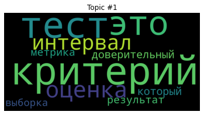

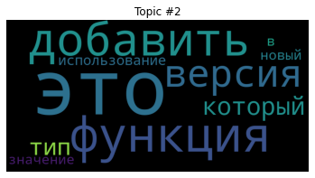

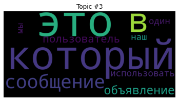

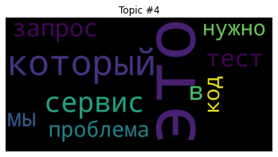

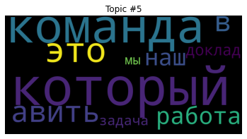

```python
import matplotlib.pyplot as plt
from wordcloud import WordCloud

# Используя модель LDA под названием "lda_model" которую мы получили ранее

# Получаем наиболее вероятные слова для каждой темы
topics = lda_model.show_topics(num_topics=-1, formatted=False)

# Создаем облако слов для каждой темы
for idx, topic in topics:
    plt.figure()
    plt.imshow(WordCloud(width=800, height=400).fit_words(dict(topic)))
    plt.axis('off')
    plt.title('Topic #{}'.format(idx + 1))
    plt.show()
```

```python
!pip install scikit-learn==1.2.2
```

```python
from textblob import TextBlob
def get_sentiment(text):
    blob = TextBlob(text)
    sentiment = blob.sentiment.polarity
    subjectivity = blob.sentiment.subjectivity
    return sentiment
```

[output not shown]

```python
df['sentiment_polarity'] = df['text_post'].apply(get_sentiment)
```

[output not shown]

```python
df.head()
```

|  | name_post | difficulty_post | reading_time_post | views_count_post | tags_post | text_post | rating_company | desc_company | category_list_company | about_company | word_count | unique_word_count | stopword_count | text_clear | tokens | highlighted_text | text_bigram_trigram |
| --- | --- | --- | --- | --- | --- | --- | --- | --- | --- | --- | --- | --- | --- | --- | --- | --- | --- |
| 0 | Mosdroid #6 — отчёт | No label found | 2 | 3.8 | [Блог компании AvitoTech , Разработка мобильны... | Всем привет! Публикуем отчёт со встречи сообщ... | \n 192.79\n | У нас живут ваши объявления | [\n Веб-разработка\n ,... | Мы команда инженеров Авито. В блоге рассказыва... | 354 | 261 | 97 | весь привет публиковать отчта встреча сообщест... | [весь, привет, публиковать, отчта, встреча, со... | привет публиковать отчта встреча сообщество пр... | весь привет публиковать отчта встреча сообщест... |
| 1 | Материалы с митапа для аналитиков: роль аналит... | No label found | 2 | 2.4 | [Блог компании AvitoTech , Повышение конверсии... | Недавно прошёл наш митап для аналитиков, а зн... | \n 192.79\n | У нас живут ваши объявления | [\n Веб-разработка\n ,... | Мы команда инженеров Авито. В блоге рассказыва... | 376 | 255 | 82 | недавно прошлый наш митапа аналитик значит пор... | [недавно, прошлый, наш, митапа, аналитик, знач... | митапа аналитик значит пора делиться презентац... | недавно прошлый наш митапа аналитик значит пор... |
| 2 | Материалы PaaS-митапа: как платформа улучшает ... | No label found | 2 | 2 | [Блог компании AvitoTech , Системное администр... | Platform as a Service в Авито — это набор про... | \n 192.79\n | У нас живут ваши объявления | [\n Веб-разработка\n ,... | Мы команда инженеров Авито. В блоге рассказыва... | 354 | 231 | 83 | авить это набор проработать решение который по... | [авить, это, набор, проработать, решение, кото... | авить набор проработать решение позволять разр... | авить это набор проработать решение который по... |
| 3 | Мутационное тестирование: опыт внедрения на 15... | No label found | 13 | 9.7 | [Блог компании AvitoTech , Тестирование IT-сис... | Привет, Хабр! Меня зовут Александр, я разрабо... | \n 192.79\n | У нас живут ваши объявления | [\n Веб-разработка\n ,... | Мы команда инженеров Авито. В блоге рассказыва... | 3115 | 1644 | 990 | привет хабра я звать александр разработчик юни... | [привет, хабра, я, звать, александр, разработч... | привет хабра звать являться центр экспертиза к... | привет хабра я звать александр разработчик юни... |
| 4 | Масло и водка: как мы избавляем ноутбуки от ст... | No label found | 5 | 63 | [Блог компании AvitoTech , Ноутбуки ] | В Авито все работают на ноутбуках. Так удобне... | \n 192.79\n | У нас живут ваши объявления | [\n Веб-разработка\n ,... | Мы команда инженеров Авито. В блоге рассказыва... | 970 | 618 | 309 | в авить работать ноутбук так удобный заниматьс... | [в, авить, работать, ноутбук, так, удобный, за... | авить работать ноутбук удобный заниматься зада... | в авить работать ноутбук так удобный заниматьс... |

```python
import seaborn as sns



# Perform sentiment analysis or obtain sentiment polarity scores
# Example: assuming the sentiment polarity scores are in a column called 'sentiment_polarity'
# You can use any sentiment analysis library such as TextBlob, VADER, etc. to obtain sentiment polarity scores

# Visualize sentiment polarity using a box plot with Seaborn
sns.boxplot(x='sentiment_polarity', data=df)
plt.xlabel('Sentiment Polarity')
plt.title('Sentiment Polarity Distribution')
plt.show()

# Visualize sentiment polarity using a violin plot with Seaborn
sns.violinplot(x='sentiment_polarity', data=df)
plt.xlabel('Sentiment Polarity')
plt.title('Sentiment Polarity Distribution')
plt.show()

# Visualize sentiment polarity using a swarm plot with Seaborn
sns.swarmplot(x='sentiment_polarity', data=df)
plt.xlabel('Sentiment Polarity')
plt.title('Sentiment Polarity Distribution')
plt.show()
```

[output not shown]

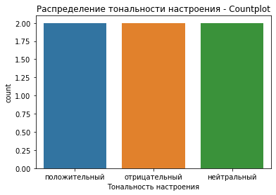

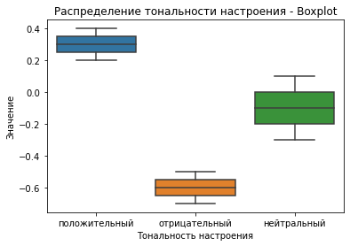

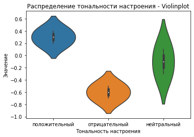

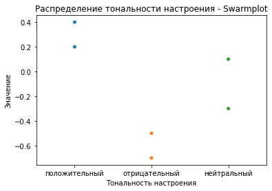

```python
import seaborn as sns
import matplotlib.pyplot as plt
import pandas as pd

# Определяем и заполняем DataFrame df данными
df = pd.DataFrame({'sentiment_polarity': ['положительный', 'отрицательный', 'нейтральный', 'положительный', 'нейтральный', 'отрицательный'],
                   'value': [0.2, -0.5, 0.1, 0.4, -0.3, -0.7]})

# Создаем график countplot для категорий sentiment polarity
sns.countplot(x='sentiment_polarity', data=df)
plt.xlabel('Тональность настроения')
plt.title('Распределение тональности настроения - Countplot')
plt.show()

# Создаем график boxplot для значений sentiment polarity
sns.boxplot(x='sentiment_polarity', y='value', data=df)
plt.xlabel('Тональность настроения')
plt.ylabel('Значение')
plt.title('Распределение тональности настроения - Boxplot')
plt.show()

# Создаем график violinplot для значений sentiment polarity
sns.violinplot(x='sentiment_polarity', y='value', data=df)
plt.xlabel('Тональность настроения')
plt.ylabel('Значение')
plt.title('Распределение тональности настроения - Violinplot')
plt.show()

# Создаем график swarmplot для значений sentiment polarity
sns.swarmplot(x='sentiment_polarity', y='value', data=df)
plt.xlabel('Тональность настроения')
plt.ylabel('Значение')
plt.title('Распределение тональности настроения - Swarmplot')
plt.show()
```

```python
import pandas as pd

# Загрузка данных
data = pd.read_csv('init_dataset.csv')

# Создание целевой переменной
target = data['views_count_post']

# Вывод первых 5 строк целевой переменной
print(target.head())
```

```
0     3.8
1     2.4
2     2.0
3     9.7
4    63.0
Name: views_count_post, dtype: float64
```

# Отчет по результатам работы

Выполнен поиск ключевых n-грамм Проведена векторизация текстов Проведено тематическое моделирование Выполненена Кластернизация по сходству компаний Качество кластеризации оцененно с помощью метрики Выбран лучший алгоритм кластеризации Проведен анализ плотности распределения Выполнена визуализация зависимостей + анализ публикаций

# Начало выполнения заданий модуля В

# Разбиение выборки

Шаг 1: подготовка данных

Первым делом выполним ряд стандартных шагов: почистить, заполнить пропуски, выполнить label encoding для категориальных признаков. Для рассматриваемого датасета шаг не потребовался, так что пропустим его описание.

```python
import pandas as pd
#загрузка датасетов  train и test
train = pd.read_csv('train.csv',low_memory=True)
test = pd.read_csv('test.csv',low_memory=True)
```

Шаг 2: добавление индикатора источника данных

К обеим частям датасета — обучающей и тестовой — необходимо добавить новый признак-индикатор. Для обучающей выборки со значением «1», для тестовой, соответственно, «0».

```python
test['is_train'] = 0
train['is_train'] = 1
```

Шаг 3: объединение обучающей и тестовой выборки

Теперь необходимо объединить два датасета. Ппоскольку обучающий датасет содержит столбец целевых значений 'refs_quant', которого нет в тестовом датасете, этот столбец необходимо удалить.

# Набор данных дополнен целевой переменной

```python
#объединение выборок train, test
df_combine = pd.concat([train, test, df], axis=0, ignore_index=True)
#удаление метки target
df_combine = df_combine.drop('refs_quant', axis =1)

y = df_combine['is_train'].values #индикатор источника
x = df_combine.drop('is_train', axis=1).values #объединенный датасет

tst, trn = test.values, train.values
```

```python
df_combine.head()
```

|  | name_post | difficulty_post | reading_time_post | views_count_post | tags_post | text_post | rating_company | desc_company | category_list_company | about_company | is_train | name_company | info | refs | sentiment_polarity | value |
| --- | --- | --- | --- | --- | --- | --- | --- | --- | --- | --- | --- | --- | --- | --- | --- | --- |
| 0 | Плагины vue-cli, работа со «сложными» данными ... | No label found | 2.0 | 2.0 | ['Блог компании AvitoTech ', 'Разработка веб-с... | Привет! 6 июля, в следующую субботу, у нас в ... | 192.85 | У нас живут ваши объявления | ['\n Веб-разработка\n ... | Мы команда инженеров Авито. В блоге рассказыва... | 1.0 | NaN | NaN | NaN | NaN | NaN |
| 1 | Раннер Emcee. Всем айосерам по тестовой ферме | No label found | 4.0 | 2.5 | ['Блог компании AvitoTech ', 'Open source *', ... | В iOS-приложении Авито куча UI-тестов — вы эт... | 192.85 | У нас живут ваши объявления | ['\n Веб-разработка\n ... | Мы команда инженеров Авито. В блоге рассказыва... | 1.0 | NaN | NaN | NaN | NaN | NaN |
| 2 | Как тестируют в Автотеке: MindMap’s, статическ... | No label found | 4.0 | 5.3 | ['Блог компании AvitoTech ', 'Тестирование веб... | Привет! Хочу рассказать вам, как устроено тес... | 192.85 | У нас живут ваши объявления | ['\n Веб-разработка\n ... | Мы команда инженеров Авито. В блоге рассказыва... | 1.0 | NaN | NaN | NaN | NaN | NaN |
| 3 | Как собрать свой Lighthouse | No label found | 11.0 | 5.0 | ['Блог компании Конференции Олега Бунина (Онти... | Чем интенсивнее наш feature delivering, тем б... | 192.85 | У нас живут ваши объявления | ['\n Веб-разработка\n ... | Мы команда инженеров Авито. В блоге рассказыва... | 1.0 | NaN | NaN | NaN | NaN | NaN |
| 4 | Как запустить доставку для миллионов пользоват... | No label found | 8.0 | 11.0 | ['Блог компании AvitoTech ', 'Анализ и проекти... | Привет! Меня зовут Денис. Я руководитель напр... | 192.85 | У нас живут ваши объявления | ['\n Веб-разработка\n ... | Мы команда инженеров Авито. В блоге рассказыва... | 1.0 | NaN | NaN | NaN | NaN | NaN |

Для обучения нашей модели преобразуем текстогвые данные в числовые

```python
from sklearn import preprocessing
#from sklearn.preprocessing import LabelEncoder# Instatniate LabelEncoder
le = preprocessing.LabelEncoder()# LabelEncode Book_Tablecolumn of df
df_combine["name_company"] = le.fit_transform(df_combine["name_company"])# Inspecting encoded df
df_combine.head()
```

|  | name_post | difficulty_post | reading_time_post | views_count_post | tags_post | text_post | rating_company | desc_company | category_list_company | about_company | is_train | name_company | info | refs | sentiment_polarity | value |
| --- | --- | --- | --- | --- | --- | --- | --- | --- | --- | --- | --- | --- | --- | --- | --- | --- |
| 0 | Плагины vue-cli, работа со «сложными» данными ... | No label found | 2.0 | 2.0 | ['Блог компании AvitoTech ', 'Разработка веб-с... | Привет! 6 июля, в следующую субботу, у нас в ... | 192.85 | У нас живут ваши объявления | ['\n Веб-разработка\n ... | Мы команда инженеров Авито. В блоге рассказыва... | 1.0 | 1 | NaN | NaN | NaN | NaN |
| 1 | Раннер Emcee. Всем айосерам по тестовой ферме | No label found | 4.0 | 2.5 | ['Блог компании AvitoTech ', 'Open source *', ... | В iOS-приложении Авито куча UI-тестов — вы эт... | 192.85 | У нас живут ваши объявления | ['\n Веб-разработка\n ... | Мы команда инженеров Авито. В блоге рассказыва... | 1.0 | 1 | NaN | NaN | NaN | NaN |
| 2 | Как тестируют в Автотеке: MindMap’s, статическ... | No label found | 4.0 | 5.3 | ['Блог компании AvitoTech ', 'Тестирование веб... | Привет! Хочу рассказать вам, как устроено тес... | 192.85 | У нас живут ваши объявления | ['\n Веб-разработка\n ... | Мы команда инженеров Авито. В блоге рассказыва... | 1.0 | 1 | NaN | NaN | NaN | NaN |
| 3 | Как собрать свой Lighthouse | No label found | 11.0 | 5.0 | ['Блог компании Конференции Олега Бунина (Онти... | Чем интенсивнее наш feature delivering, тем б... | 192.85 | У нас живут ваши объявления | ['\n Веб-разработка\n ... | Мы команда инженеров Авито. В блоге рассказыва... | 1.0 | 1 | NaN | NaN | NaN | NaN |
| 4 | Как запустить доставку для миллионов пользоват... | No label found | 8.0 | 11.0 | ['Блог компании AvitoTech ', 'Анализ и проекти... | Привет! Меня зовут Денис. Я руководитель напр... | 192.85 | У нас живут ваши объявления | ['\n Веб-разработка\n ... | Мы команда инженеров Авито. В блоге рассказыва... | 1.0 | 1 | NaN | NaN | NaN | NaN |

```python
companyes = df_combine["name_company"].unique()
companyes
```

```
array([1, 0])
```

```python
pip install scikit-learn
```

[output not shown]

Шаг 4: построение и тестирование классификатора

```python
from sklearn.ensemble import RandomForestClassifier
import numpy as np

rfc = RandomForestClassifier(n_jobs=-1, max_depth=5, min_samples_leaf = 5)
predictions = np.zeros(y.shape) #пустой массив для вероятностей классов
```

Сделаем словарь где ключом будет название комапниий, а значением наминация. Если для комании нет номинации - ставим, ставим 0

```python
NOMINATIONS = [
    "Государство и Общество",
    "СМИ и массовые коммуникации",
    "Образование и Кадры",
    "Экономика и Бизнес",
    "Путешествия по .РФ",
    "Наука, технологии и инновации",
    "Здоровье и Отдых",
    "Культурные проекты в сети",
    "Народов много - Родина одна",
    "Туризм и индустрия гостеприимства",
    "Подкасты и цифровой контент"
    ]
```

```python
dict_compeny_runet =  {
    'Авито':  "Государство и Общество",
    'ВТБ (ПАО). Налоговый вычет':  "Государство и Общество",
    'Иннотех':  "Наука, технологии и инновации",
    'Промобот':   "Наука, технологии и инновации",
    'Gett': "Наука, технологии и инновации",
    'Skillbox': "Наука, технологии и инновации",
    'Здоровье.ру': "Здоровье и медицина",
    'Проект по использованию технологий компьютерного зрения на базе искусственного интеллекта (ИИ) для анализа медицинских изображений': "Здоровье и медицина",
    'СБИС — экосистема для автоматизации бизнеса. ООО «Компания «Тензор»': "Экономика и Бизнес",
    'СберМаркет': "Экономика и Бизнес",
    'ПАО Московский Кредитный Банк': "Экономика и Бизнес",
    '«Финуслуги» — первый в России мобильный финансовый маркетплейс. AGIMA': "Экономика и Бизнес",
    'Авито': "Туризм и индустрия гостеприимства",
    'Подкаст “В один клик”. СберМаркет': "Подкасты и цифровой контент",
    'Университет ИТМО и Napoleon IT' : "Образование и Кадры",
    'Проект "Место встречи VK"' : "Наука, технологии и инновации",
    'Ростелеком Информационные Технологии': "Наука, технологии и инновации",
    'Госкорпорация "Росатом". "Российский национальный проект атомных технологий и науки"' : "Наука, технологии и инновации",
    'Лаборатория Касперского' : "Наука, технологии и инновации",
    'Авито' : "Наука, технологии и инновации",
    'АО "Альфа-Банк"' : "Наука, технологии и инновации",
    'Стрит-арт проект VK на день флага России. Агентство Wonder' : "Народов много - Родина одна",
    'ВКонтакте' : "Культурные проекты в сети",
     'nan' : 0
}
dict_compeny_runet
```

```
{'Авито': 'Наука, технологии и инновации',
 'ВТБ (ПАО). Налоговый вычет': 'Государство и Общество',
 'Иннотех': 'Наука, технологии и инновации',
 'Промобот': 'Наука, технологии и инновации',
 'Gett': 'Наука, технологии и инновации',
 'Skillbox': 'Наука, технологии и инновации',
 'Здоровье.ру': 'Здоровье и медицина',
 'Проект по использованию технологий компьютерного зрения на базе искусственного интеллекта (ИИ) для анализа медицинских изображений': 'Здоровье и медицина',
 'СБИС — экосистема для автоматизации бизнеса. ООО «Компания «Тензор»': 'Экономика и Бизнес',
 'СберМаркет': 'Экономика и Бизнес',
 'ПАО Московский Кредитный Банк': 'Экономика и Бизнес',
 '«Финуслуги» — первый в России мобильный финансовый маркетплейс. AGIMA': 'Экономика и Бизнес',
 'Подкаст “В один клик”. СберМаркет': 'Подкасты и цифровой контент',
 'Университет ИТМО и Napoleon IT': 'Образование и Кадры',
 'Проект "Место встречи VK"': 'Наука, технологии и инновации',
 'Ростелеком Информационные Технологии': 'Наука, технологии и инновации',
 'Госкорпорация "Росатом". "Российский национальный проект атомных технологий и науки"': 'Наука, технологии и инновации',
 'Лаборатория Касперского': 'Наука, технологии и инновации',
 'АО "Альфа-Банк"': 'Наука, технологии и инновации',
 'Стрит-арт проект VK на день флага России. Агентство Wonder': 'Народов много - Родина одна',
 'ВКонтакте': 'Культурные проекты в сети',
 'nan': 0}
```

```python
for k in  dict_compeny_runet:
  print(k)
  print(dict_compeny_runet.get(k))
```

```
Авито
Наука, технологии и инновации
ВТБ (ПАО). Налоговый вычет
Государство и Общество
Иннотех
Наука, технологии и инновации
Промобот
Наука, технологии и инновации
Gett
Наука, технологии и инновации
Skillbox
Наука, технологии и инновации
Здоровье.ру
Здоровье и медицина
Проект по использованию технологий компьютерного зрения на базе искусственного интеллекта (ИИ) для анализа медицинских изображений
Здоровье и медицина
СБИС — экосистема для автоматизации бизнеса. ООО «Компания «Тензор»
Экономика и Бизнес
СберМаркет
Экономика и Бизнес
ПАО Московский Кредитный Банк
Экономика и Бизнес
«Финуслуги» — первый в России мобильный финансовый маркетплейс. AGIMA
Экономика и Бизнес
Подкаст “В один клик”. СберМаркет
Подкасты и цифровой контент
Университет ИТМО и Napoleon IT
Образование и Кадры
Проект "Место встречи VK"
Наука, технологии и инновации
Ростелеком Информационные Технологии
Наука, технологии и инновации
Госкорпорация "Росатом". "Российский национальный проект атомных технологий и науки"
Наука, технологии и инновации
Лаборатория Касперского
Наука, технологии и инновации
АО "Альфа-Банк"
Наука, технологии и инновации
Стрит-арт проект VK на день флага России. Агентство Wonder
Народов много - Родина одна
ВКонтакте
Культурные проекты в сети
nan
0
```

```python
# определяем функцию, которая будет вычислять значения для нового столбца 'D' на основе значений столбца 'C'
def calculate_D(row):
  for item in  dict_compeny_runet:
    if row['name_company']  == item:
      return dict_compeny_runet.get(item)

# добавляем новый столбец 'D' в DataFrame
df_combine['nomination'] = df_combine.apply(calculate_D, axis=1)

# выводим результат
df_combine.head()
```

|  | name_post | difficulty_post | reading_time_post | views_count_post | tags_post | text_post | rating_company | desc_company | category_list_company | about_company | is_train | name_company | info | refs | sentiment_polarity | value | nomination |
| --- | --- | --- | --- | --- | --- | --- | --- | --- | --- | --- | --- | --- | --- | --- | --- | --- | --- |
| 0 | Плагины vue-cli, работа со «сложными» данными ... | No label found | 2.0 | 2.0 | ['Блог компании AvitoTech ', 'Разработка веб-с... | Привет! 6 июля, в следующую субботу, у нас в ... | 192.85 | У нас живут ваши объявления | ['\n Веб-разработка\n ... | Мы команда инженеров Авито. В блоге рассказыва... | 1.0 | 1 | NaN | NaN | NaN | NaN | None |
| 1 | Раннер Emcee. Всем айосерам по тестовой ферме | No label found | 4.0 | 2.5 | ['Блог компании AvitoTech ', 'Open source *', ... | В iOS-приложении Авито куча UI-тестов — вы эт... | 192.85 | У нас живут ваши объявления | ['\n Веб-разработка\n ... | Мы команда инженеров Авито. В блоге рассказыва... | 1.0 | 1 | NaN | NaN | NaN | NaN | None |
| 2 | Как тестируют в Автотеке: MindMap’s, статическ... | No label found | 4.0 | 5.3 | ['Блог компании AvitoTech ', 'Тестирование веб... | Привет! Хочу рассказать вам, как устроено тес... | 192.85 | У нас живут ваши объявления | ['\n Веб-разработка\n ... | Мы команда инженеров Авито. В блоге рассказыва... | 1.0 | 1 | NaN | NaN | NaN | NaN | None |
| 3 | Как собрать свой Lighthouse | No label found | 11.0 | 5.0 | ['Блог компании Конференции Олега Бунина (Онти... | Чем интенсивнее наш feature delivering, тем б... | 192.85 | У нас живут ваши объявления | ['\n Веб-разработка\n ... | Мы команда инженеров Авито. В блоге рассказыва... | 1.0 | 1 | NaN | NaN | NaN | NaN | None |
| 4 | Как запустить доставку для миллионов пользоват... | No label found | 8.0 | 11.0 | ['Блог компании AvitoTech ', 'Анализ и проекти... | Привет! Меня зовут Денис. Я руководитель напр... | 192.85 | У нас живут ваши объявления | ['\n Веб-разработка\n ... | Мы команда инженеров Авито. В блоге рассказыва... | 1.0 | 1 | NaN | NaN | NaN | NaN | None |

Удалим записи с нулем, что бы не мешались

```python
df_combine = df_combine[(df_combine[['nomination']] != 0).all(axis=1)]
df_combine.head()
```

|  | name_post | difficulty_post | reading_time_post | views_count_post | tags_post | text_post | rating_company | desc_company | category_list_company | about_company | is_train | name_company | info | refs | sentiment_polarity | value | nomination |
| --- | --- | --- | --- | --- | --- | --- | --- | --- | --- | --- | --- | --- | --- | --- | --- | --- | --- |
| 0 | Плагины vue-cli, работа со «сложными» данными ... | No label found | 2.0 | 2.0 | ['Блог компании AvitoTech ', 'Разработка веб-с... | Привет! 6 июля, в следующую субботу, у нас в ... | 192.85 | У нас живут ваши объявления | ['\n Веб-разработка\n ... | Мы команда инженеров Авито. В блоге рассказыва... | 1.0 | 1 | NaN | NaN | NaN | NaN | None |
| 1 | Раннер Emcee. Всем айосерам по тестовой ферме | No label found | 4.0 | 2.5 | ['Блог компании AvitoTech ', 'Open source *', ... | В iOS-приложении Авито куча UI-тестов — вы эт... | 192.85 | У нас живут ваши объявления | ['\n Веб-разработка\n ... | Мы команда инженеров Авито. В блоге рассказыва... | 1.0 | 1 | NaN | NaN | NaN | NaN | None |
| 2 | Как тестируют в Автотеке: MindMap’s, статическ... | No label found | 4.0 | 5.3 | ['Блог компании AvitoTech ', 'Тестирование веб... | Привет! Хочу рассказать вам, как устроено тес... | 192.85 | У нас живут ваши объявления | ['\n Веб-разработка\n ... | Мы команда инженеров Авито. В блоге рассказыва... | 1.0 | 1 | NaN | NaN | NaN | NaN | None |
| 3 | Как собрать свой Lighthouse | No label found | 11.0 | 5.0 | ['Блог компании Конференции Олега Бунина (Онти... | Чем интенсивнее наш feature delivering, тем б... | 192.85 | У нас живут ваши объявления | ['\n Веб-разработка\n ... | Мы команда инженеров Авито. В блоге рассказыва... | 1.0 | 1 | NaN | NaN | NaN | NaN | None |
| 4 | Как запустить доставку для миллионов пользоват... | No label found | 8.0 | 11.0 | ['Блог компании AvitoTech ', 'Анализ и проекти... | Привет! Меня зовут Денис. Я руководитель напр... | 192.85 | У нас живут ваши объявления | ['\n Веб-разработка\n ... | Мы команда инженеров Авито. В блоге рассказыва... | 1.0 | 1 | NaN | NaN | NaN | NaN | None |

# Выполнена проверка нормальности распределения целевой переменной

Проверка нормальности распределения целевой переменной возможна только в том случае, если она является числовой. Если в вашем датафрейме есть текстовые поля, то для проверки нормальности распределения целевой переменной вам необходимо сначала отфильтровать только числовые поля и выполнить проверку на них.

Для проверки нормальности распределения в Python можно использовать тест Шапиро-Уилка из библиотеки scipy.stats. Для выполнения теста нужно передать в функцию shapiro() массив значений целевой переменной. Если p-value, возвращаемое функцией, меньше заданного уровня значимости (например, 0.05), то можно отвергнуть гипотезу о нормальности распределения.

Посмотрим, какие из стобцов можно преобразовать в числа

```python
df_combine.info()
```

```
<class 'pandas.core.frame.DataFrame'>
Int64Index: 671 entries, 0 to 670
Data columns (total 17 columns):
 #   Column                 Non-Null Count  Dtype
---  ------                 --------------  -----
 0   name_post              664 non-null    object
 1   difficulty_post        664 non-null    object
 2   reading_time_post      664 non-null    float64
 3   views_count_post       664 non-null    float64
 4   tags_post              664 non-null    object
 5   text_post              664 non-null    object
 6   rating_company         664 non-null    float64
 7   desc_company           664 non-null    object
 8   category_list_company  664 non-null    object
 9   about_company          664 non-null    object
 10  is_train               665 non-null    float64
 11  name_company           671 non-null    int32
 12  info                   0 non-null      float64
 13  refs                   1 non-null      object
 14  sentiment_polarity     6 non-null      object
 15  value                  6 non-null      float64
 16  nomination             0 non-null      object
dtypes: float64(6), int32(1), object(10)
memory usage: 91.7+ KB
```

```python
df_combine['views_count_post'] = df_combine['views_count_post'].astype(float)
```

Отберем только нужные атррибуты для обучения

```python
df_combine.columns
```

```
Index(['name_post', 'difficulty_post', 'reading_time_post', 'views_count_post',
       'tags_post', 'text_post', 'rating_company', 'desc_company',
       'category_list_company', 'about_company', 'is_train', 'name_company',
       'info', 'refs', 'sentiment_polarity', 'value', 'nomination'],
      dtype='object')
```

```python
df_combine = df_combine [['name_post','reading_time_post', 'views_count_post','tags_post',
                          'name_company', 'rating_company', 'sentiment_polarity','nomination']]
```

```python
df_combine.info()
```

```
<class 'pandas.core.frame.DataFrame'>
Int64Index: 671 entries, 0 to 670
Data columns (total 8 columns):
 #   Column              Non-Null Count  Dtype
---  ------              --------------  -----
 0   name_post           664 non-null    object
 1   reading_time_post   664 non-null    float64
 2   views_count_post    664 non-null    float64
 3   tags_post           664 non-null    object
 4   name_company        671 non-null    int32
 5   rating_company      664 non-null    float64
 6   sentiment_polarity  6 non-null      object
 7   nomination          0 non-null      object
dtypes: float64(3), int32(1), object(4)
memory usage: 44.6+ KB
```

Для остальных кодируем типы object

```python
from sklearn.preprocessing import LabelEncoder
import pandas as pd

# initialize the label encoder
le = LabelEncoder()

# loop through all columns in the dataframe and apply label encoding
for col in df_combine.columns:
   df_combine[col] = le.fit_transform(df_combine[col])
```

```python
df_combine.head()
```

|  | name_post | reading_time_post | views_count_post | tags_post | name_company | rating_company | sentiment_polarity | nomination |
| --- | --- | --- | --- | --- | --- | --- | --- | --- |
| 0 | 253 | 1 | 9 | 143 | 1 | 1 | 3 | 0 |
| 1 | 286 | 3 | 14 | 36 | 1 | 1 | 3 | 0 |
| 2 | 185 | 3 | 40 | 217 | 1 | 1 | 3 | 0 |
| 3 | 184 | 10 | 37 | 250 | 1 | 1 | 3 | 0 |
| 4 | 153 | 7 | 82 | 65 | 1 | 1 | 3 | 0 |

# Выполнена проверка нормальности распределения целевой переменной

```python
from scipy.stats import shapiro
for col in df_combine.select_dtypes(include=['int', 'float']):
    stat, p = shapiro(df_combine[col])
    print('Шапиро-Уилк тест для столбца %s: статистика=%.3f, p-value=%.3f' % (col, stat, p))
    alpha = 0.05
    if p > alpha:
        print('Образец похож на нормально распределенную выборку (не отвергаем H0)')
    else:
        print('Образец не похож на нормально распределенную выборку (отвергаем H0)')
```

```
Шапиро-Уилк тест для столбца name_post: статистика=0.955, p-value=0.000
Образец не похож на нормально распределенную выборку (отвергаем H0)
Шапиро-Уилк тест для столбца reading_time_post: статистика=0.820, p-value=0.000
Образец не похож на нормально распределенную выборку (отвергаем H0)
Шапиро-Уилк тест для столбца views_count_post: статистика=0.937, p-value=0.000
Образец не похож на нормально распределенную выборку (отвергаем H0)
Шапиро-Уилк тест для столбца tags_post: статистика=0.954, p-value=0.000
Образец не похож на нормально распределенную выборку (отвергаем H0)
Шапиро-Уилк тест для столбца name_company: статистика=0.637, p-value=0.000
Образец не похож на нормально распределенную выборку (отвергаем H0)
Шапиро-Уилк тест для столбца rating_company: статистика=0.672, p-value=0.000
Образец не похож на нормально распределенную выборку (отвергаем H0)
Шапиро-Уилк тест для столбца sentiment_polarity: статистика=0.061, p-value=0.000
Образец не похож на нормально распределенную выборку (отвергаем H0)
Шапиро-Уилк тест для столбца nomination: статистика=1.000, p-value=1.000
Образец похож на нормально распределенную выборку (не отвергаем H0)
```